# Linear_Correlations

```r
daily <- read.csv('../../Data/1999_2021/aggragate_daily_data_2000to2020.csv')
names(daily)
```

```
##  [1] "X"                "date"             "energy_charge"    "effluent_flow"
##  [5] "influent_flow"    "volume_used"      "poured_flow"      "water_level"
##  [9] "energy_generated" "energy_stored"    "maximum_demand"
```

```r
lowerFn <- function(data, mapping, method = "lm", ...) {
  p <- ggplot(data = data, mapping = mapping) +
    geom_point(colour = "blue") +
    geom_smooth(method = method, color = "red", ...)
  p
}
```

**Creating correlation matrix with ggpairs**

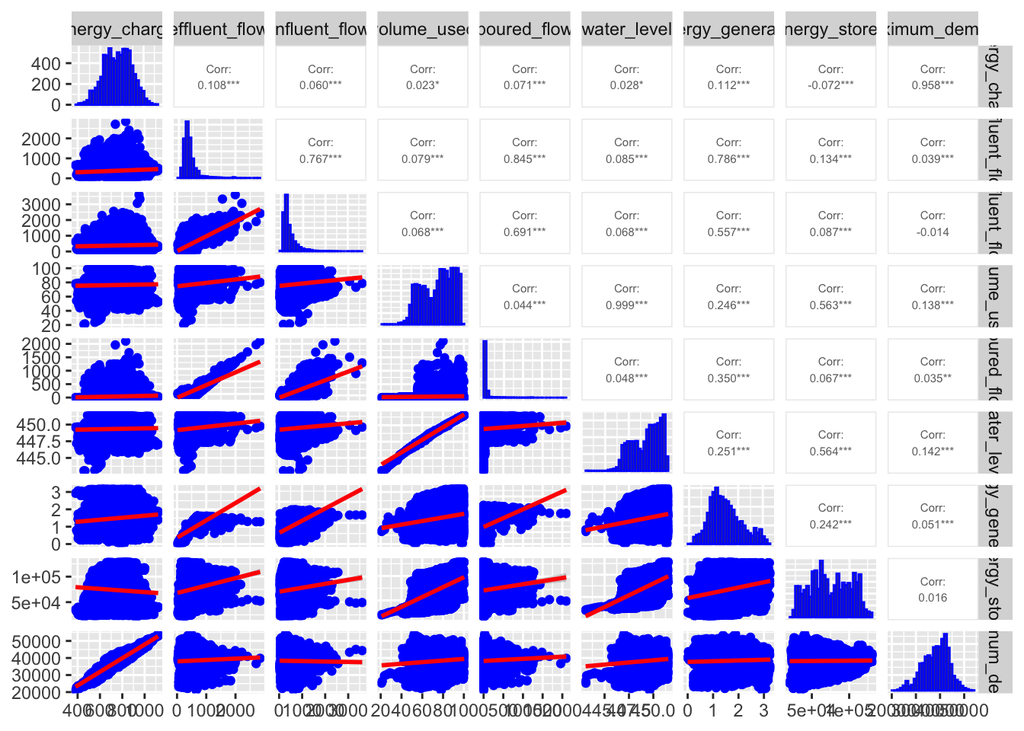

```r
pairs_plot <- ggpairs(
  daily[,3:11], lower = list(continuous = wrap(lowerFn, method = "lm")),
  diag = list(continuous = wrap("barDiag", color = "blue")),
  upper = list(continuous = wrap("cor", size = 2))
)
pairs_plot
```

**Creating table of correlations and removing redundancies**

```r
daily_trunc <- daily %>%
  select(-X, -date)

corr_table <- cor(daily_trunc) %>%
  as_tibble(rownames = "var1") %>%
    pivot_longer(cols = -var1, names_to = "var2", values_to = "coeff") %>%
    filter(var1 != var2) %>%
    arrange(desc(abs(coeff)))

corr_table <- distinct(corr_table, coeff, .keep_all = TRUE)
corr_table
```

```
## # A tibble: 36 x 3
##    var1          var2             coeff
##    <chr>         <chr>            <dbl>
##  1 volume_used   water_level      0.999
##  2 energy_charge maximum_demand   0.958
##  3 effluent_flow poured_flow      0.845
##  4 effluent_flow energy_generated 0.786
##  5 effluent_flow influent_flow    0.767
##  6 influent_flow poured_flow      0.691
##  7 water_level   energy_stored    0.564
##  8 volume_used   energy_stored    0.563
##  9 influent_flow energy_generated 0.557
## 10 poured_flow   energy_generated 0.350
## # … with 26 more rows
```

**Correlations of all variables to energy generated**

```r
energy_gen_corr <- cor(daily_trunc) %>%
  as_tibble(rownames = "var1") %>%
    pivot_longer(cols = -var1, names_to = "var2", values_to = "coeff") %>%
    filter(var1 == "energy_generated") %>%
    arrange(desc(abs(coeff)))
energy_gen_corr
```

```
## # A tibble: 9 x 3
##   var1             var2              coeff
##   <chr>            <chr>             <dbl>
## 1 energy_generated energy_generated 1
## 2 energy_generated effluent_flow    0.786
## 3 energy_generated influent_flow    0.557
## 4 energy_generated poured_flow      0.350
## 5 energy_generated water_level      0.251
## 6 energy_generated volume_used      0.246
## 7 energy_generated energy_stored    0.242
## 8 energy_generated energy_charge    0.112
## 9 energy_generated maximum_demand   0.0508
```

**Shifting influent flow, water level, effluent flow, turbine flow back and finding correlations with energy generation**

```r
lagged_daily <- daily %>%
  select(date, influent_flow, water_level, effluent_flow, energy_generated) %>%
  mutate(influent_flow_1 = lag(influent_flow, 1, order_by = date),
         influent_flow_3 = lag(influent_flow, 3, order_by = date),
         influent_flow_7 = lag(influent_flow, 7, order_by = date),
         influent_flow_21 = lag(influent_flow, 21, order_by = date),
         water_level_1 = lag( water_level, 1, order_by = date),
         water_level_3 = lag( water_level, 3, order_by = date),
         water_level_7 = lag( water_level, 7, order_by = date),
         water_level_21 = lag(water_level, 21, order_by = date),
         effluent_flow_1 = lag(effluent_flow, 1, order_by = date),
         effluent_flow_3 = lag(effluent_flow, 3, order_by = date),
         effluent_flow_7 = lag(effluent_flow, 7, order_by = date),
         effluent_flow_21 = lag(effluent_flow, 21, order_by = date)) %>%
  select(-date)


lagged_energy_gen_corr <- cor(drop_na(lagged_daily)) %>%
  as_tibble(rownames = "var1") %>%
    pivot_longer(cols = -var1, names_to = "var2", values_to = "coeff") %>%
    filter(var1 == "energy_generated") %>%
    arrange(var2)
lagged_energy_gen_corr
```

```
## # A tibble: 16 x 3
##    var1             var2             coeff
##    <chr>            <chr>            <dbl>
##  1 energy_generated effluent_flow    0.786
##  2 energy_generated effluent_flow_1  0.705
##  3 energy_generated effluent_flow_21 0.401
##  4 energy_generated effluent_flow_3  0.639
##  5 energy_generated effluent_flow_7  0.568
##  6 energy_generated energy_generated 1
##  7 energy_generated influent_flow    0.559
##  8 energy_generated influent_flow_1  0.588
##  9 energy_generated influent_flow_21 0.428
## 10 energy_generated influent_flow_3  0.606
## 11 energy_generated influent_flow_7  0.561
## 12 energy_generated water_level      0.253
## 13 energy_generated water_level_1    0.258
## 14 energy_generated water_level_21   0.101
## 15 energy_generated water_level_3    0.252
## 16 energy_generated water_level_7    0.224
```

#LASSO on additive model

```r
lasso_model <- train(
  energy_generated ~ ., data = daily_trunc,
  method = "glmnet",
  trControl = trainControl(method = "cv", number = 10),
  tuneGrid = data.frame(alpha = 1, lambda = 10^seq(-5, 1, length = 1000)),
  metric = "MAE"
)
```

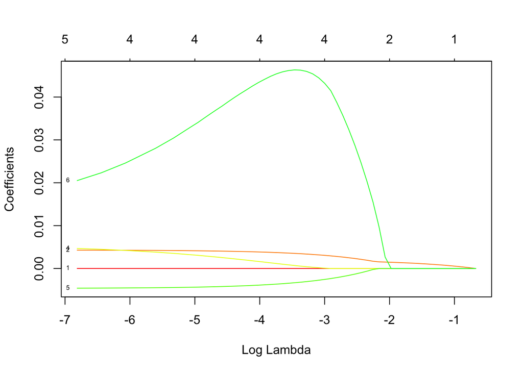

```r
# Plot coefficients for each LASSO
plot(lasso_model$finalModel, xvar = "lambda", label = TRUE, col = rainbow(11))
```

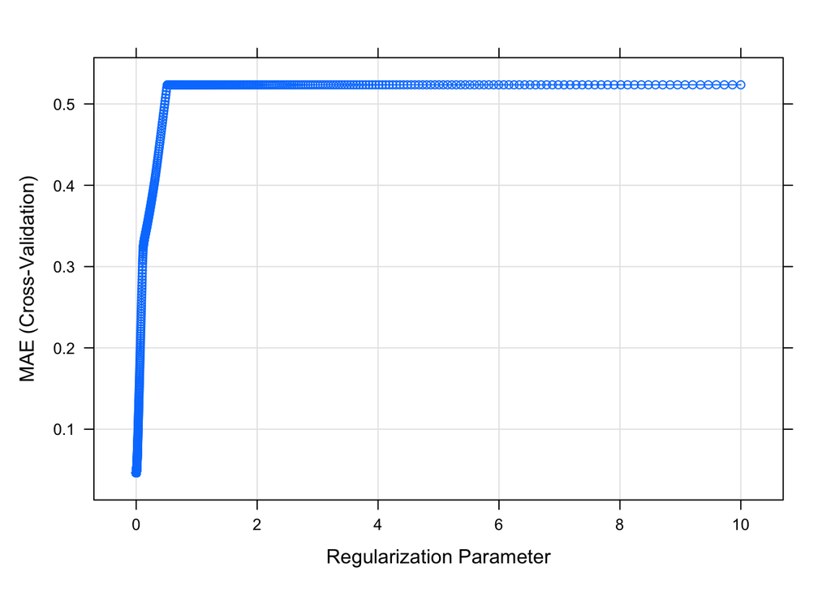

```r
plot(lasso_model)
```

```r
coef(lasso_model$finalModel, lasso_model$bestTune$lambda)
```

```
## 9 x 1 sparse Matrix of class "dgCMatrix"
##                            1
## (Intercept)    -9.529737e+00
## energy_charge   5.010094e-06
## effluent_flow   4.282761e-03
## influent_flow   .
## volume_used     4.670620e-03
## poured_flow    -4.587938e-03
## water_level     2.051661e-02
## energy_stored   .
## maximum_demand  .
```

```r
# lasso_model$results gives metrics for every LASSO at every lambda
#lasso_model$results

# Just focus on those that correspond to the best lambda
lasso_model$results %>%
  filter(lambda == lasso_model$bestTune$lambda)
```

```
##   alpha      lambda       RMSE  Rsquared        MAE      RMSESD  RsquaredSD
## 1     1 0.001086516 0.06584813 0.9897198 0.04635518 0.005731164 0.002073657
##         MAESD
## 1 0.001749818
```

Note: suspiciously high Rsquared. Possibly because turbine flow is directly related to energy generated. Attempt LASSO without these variables? Attempt LASSO with lagged variables?

**Running LASSO without poured flow, turbine flow, effluent flow, or water level**

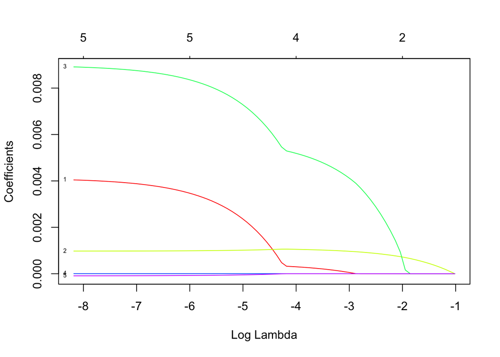

```r
lasso_model_1 <- train(
  energy_generated ~ energy_charge + influent_flow + volume_used + energy_stored + maximum_demand, data = daily_trunc,
  method = "glmnet",
  trControl = trainControl(method = "cv", number = 10),
  tuneGrid = data.frame(alpha = 1, lambda = 10^seq(-5, 1, length = 1000)),
  metric = "MAE"
)

# Plot coefficients for each LASSO
plot(lasso_model_1$finalModel, xvar = "lambda", label = TRUE, col = rainbow(5))
```

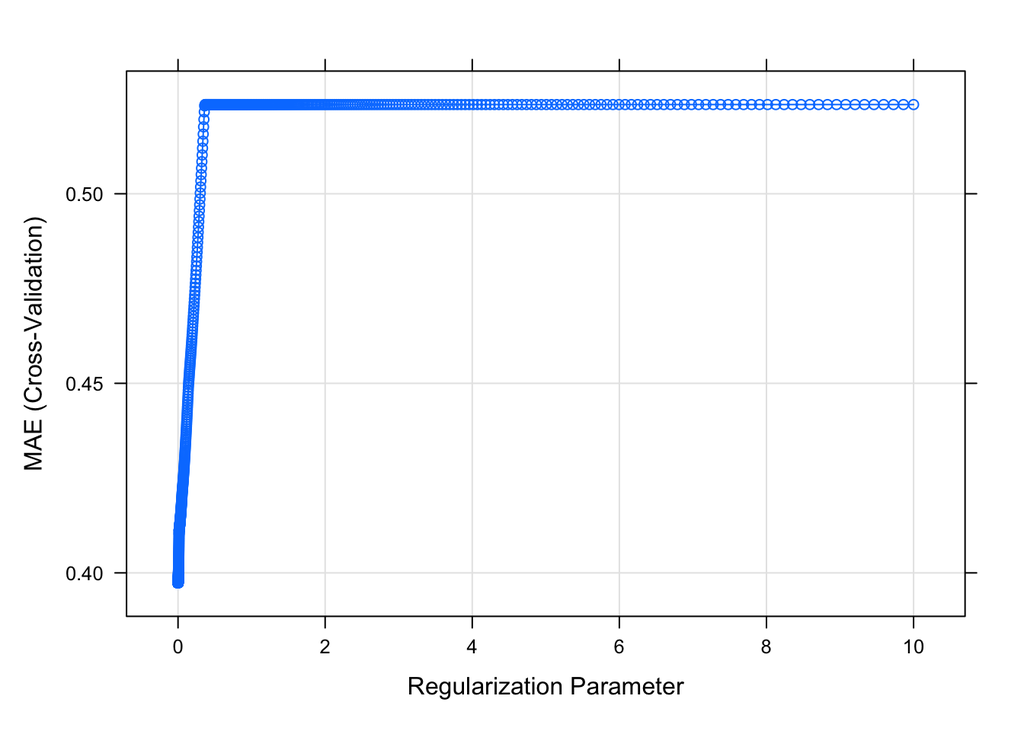

```r
plot(lasso_model_1)
```

```r
coef(lasso_model_1$finalModel, lasso_model_1$bestTune$lambda)
```

```
## 6 x 1 sparse Matrix of class "dgCMatrix"
##                            1
## (Intercept)     5.342848e-01
## energy_charge   4.043181e-03
## influent_flow   9.761606e-04
## volume_used     8.913074e-03
## energy_stored   3.517805e-06
## maximum_demand -8.947393e-05
```

```r
lasso_model_1$results %>%
  filter(lambda == lasso_model_1$bestTune$lambda)
```

```
##   alpha       lambda      RMSE  Rsquared       MAE      RMSESD RsquaredSD
## 1     1 0.0002763385 0.5021248 0.4042383 0.3973679 0.006691546 0.02585038
##        MAESD
## 1 0.00673336
```

**Notes**: Moderately significant Rsquared after removing obvious variables.

**Running LASSO with 7 day lag**

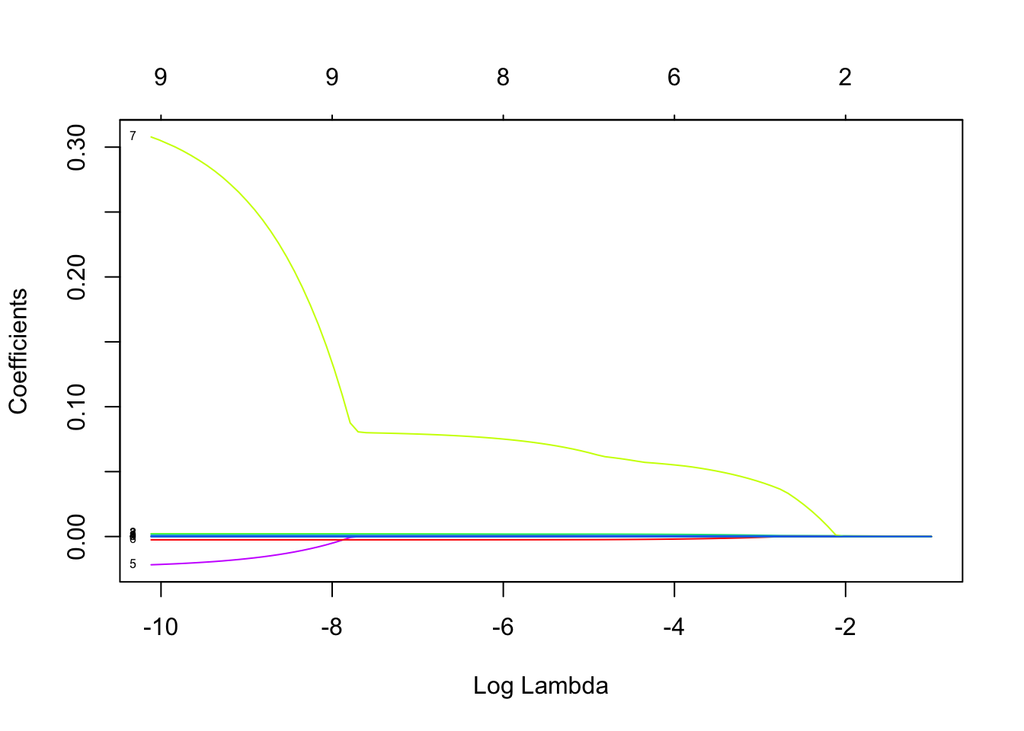

```r
daily_lagged_7 <- daily %>%
  mutate(energy_charge_7 = lag(energy_charge, 7, order_by = date),
         effluent_flow_7 = lag(effluent_flow, 7, order_by = date),
         influent_flow_7 = lag(influent_flow, 7, order_by = date),
         volume_used_7 = lag(volume_used, 7, order_by = date),
         poured_flow_7 = lag(poured_flow, 7, order_by = date),
         water_level_7 = lag(water_level, 7, order_by = date),
         energy_stored_7 = lag(energy_stored, 7, order_by = date),
         maximum_demand_7 = lag(maximum_demand, 7, order_by = date),
         ) %>%
  select(-date, -energy_charge,-effluent_flow, -influent_flow, -volume_used, -energy_stored, -poured_flow, -water_level, -energy_stored, -maximum_demand) %>%
  drop_na()

lasso_model_7 <- train(
  energy_generated ~ ., data = daily_lagged_7,
  method = "glmnet",
  trControl = trainControl(method = "cv", number = 10),
  tuneGrid = data.frame(alpha = 1, lambda = 10^seq(-5, 1, length = 1000)),
  metric = "MAE"
)

# Plot coefficients for each LASSO
plot(lasso_model_7$finalModel, xvar = "lambda", label = TRUE, col = rainbow(5))
```

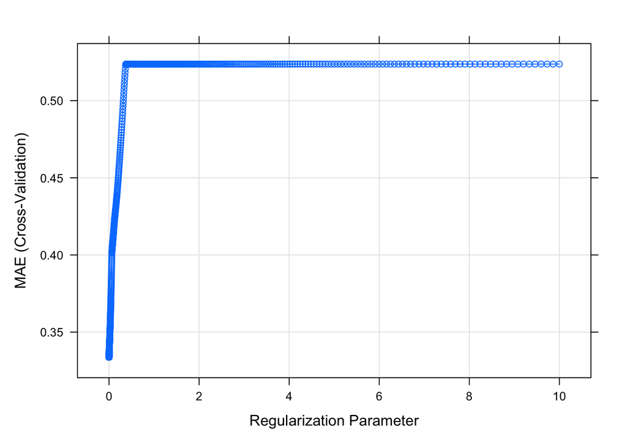

```r
plot(lasso_model_7)
```

```r
coef(lasso_model_7$finalModel, lasso_model_7$bestTune$lambda)
```

```
## 10 x 1 sparse Matrix of class "dgCMatrix"
##                              1
## (Intercept)      -1.359110e+02
## X                -6.691227e-06
## energy_charge_7   2.162389e-03
## effluent_flow_7   1.903857e-03
## influent_flow_7   7.301083e-04
## volume_used_7    -2.174691e-02
## poured_flow_7    -2.542836e-03
## water_level_7     3.078000e-01
## energy_stored_7   9.920291e-07
## maximum_demand_7 -4.801108e-05
```

```r
lasso_model_7$results %>%
  filter(lambda == lasso_model_7$bestTune$lambda)
```

```
##   alpha       lambda      RMSE  Rsquared       MAE     RMSESD RsquaredSD
## 1     1 3.986581e-05 0.4503627 0.5195526 0.3337333 0.01658473 0.03197958
##        MAESD
## 1 0.01200522
```

*Note*: Including all variables at a 7 day lag results in a higher Rsquared than using a few of them with 0 lag, but LASSO doesn’t eliminate any of them. Overfitted?

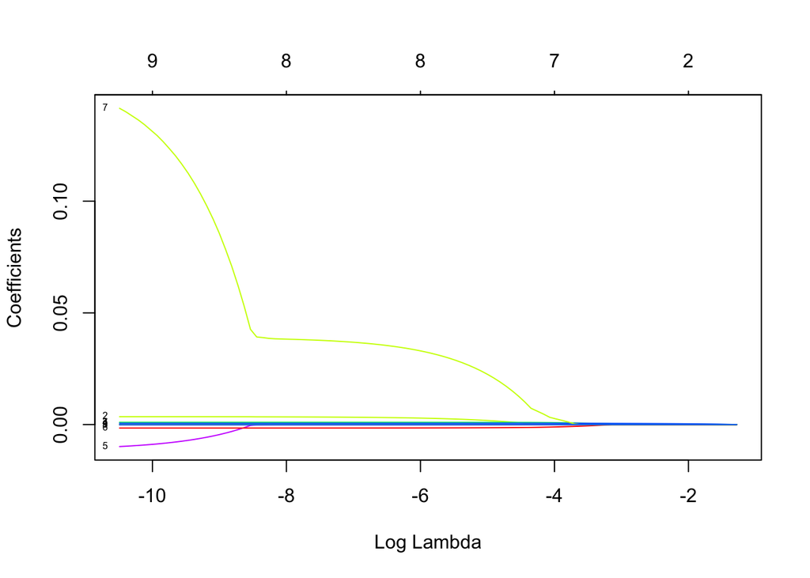

```r
daily_lagged_21 <- daily %>%
  mutate(energy_charge_21 = lag(energy_charge, 21, order_by = date),
         effluent_flow_21 = lag(effluent_flow, 21, order_by = date),
         influent_flow_21 = lag(influent_flow, 21, order_by = date),
         volume_used_21 = lag(volume_used, 21, order_by = date),
         poured_flow_21 = lag(poured_flow, 21, order_by = date),
         water_level_21 = lag(water_level, 21, order_by = date),
         energy_stored_21 = lag(energy_stored, 21, order_by = date),
         maximum_demand_21 = lag(maximum_demand, 21, order_by = date),
         ) %>%
  select(-date, -energy_charge,-effluent_flow, -influent_flow, -volume_used, -energy_stored, -poured_flow, -water_level, -energy_stored, -maximum_demand) %>%
  drop_na()

lasso_model_21 <- train(
  energy_generated ~ ., data = daily_lagged_21,
  method = "glmnet",
  trControl = trainControl(method = "cv", number = 10),
  tuneGrid = data.frame(alpha = 1, lambda = 10^seq(-5, 1, length = 1000)),
  metric = "MAE"
)

# Plot coefficients for each LASSO
plot(lasso_model_21$finalModel, xvar = "lambda", label = TRUE, col = rainbow(5))
```

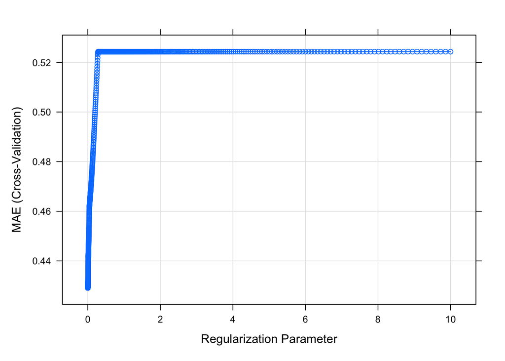

```r
plot(lasso_model_21)
```

```r
coef(lasso_model_21$finalModel, lasso_model_21$bestTune$lambda)
```

```
## 10 x 1 sparse Matrix of class "dgCMatrix"
##                               1
## (Intercept)       -3.199048e+01
## X                 -4.196341e-06
## energy_charge_21   3.507378e-03
## effluent_flow_21   1.041427e-03
## influent_flow_21   6.223311e-04
## volume_used_21    -3.409312e-03
## poured_flow_21    -1.544270e-03
## water_level_21     7.435312e-02
## energy_stored_21   1.997622e-06
## maximum_demand_21 -7.925847e-05
```

```r
lasso_model_21$results %>%
  filter(lambda == lasso_model_21$bestTune$lambda)
```

```
##   alpha      lambda      RMSE Rsquared       MAE     RMSESD RsquaredSD
## 1     1 0.000142283 0.5504218 0.284423 0.4291461 0.01737481 0.02317485
##        MAESD
## 1 0.01284688
```

*Note*: significant drop in Rsquared, terrible estimate.

# Conclusion

LASSO is not useful here, especially if we want to predict anything.